# Homework-3

Alana Pengilley

15/04/2021

### Challenge 1

For this exercise, the end aim is to fit a simple linear regression model to predict weaning age (WeaningAge_d) measured in days from species’ brain size (Brain_Size_Species_Mean) measured in grams.

```r
library(readr)
library(ggplot2)
library(broom)
library(tidyverse)
library(dplyr)
```

Load in Kamilar and Cooper Data

```r
f <- "https://raw.githubusercontent.com/difiore/ada-2021-datasets/main/KamilarAndCooperData.csv"
d <- read_csv(f, col_names = T)
head(d)
```

```
## # A tibble: 6 x 44
##   Scientific_Name Family Genus Species Brain_Size_Spec… Brain_Size_Fema…
##   <chr>           <chr>  <chr> <chr>              <dbl>            <dbl>
## 1 Allenopithecus… Cerco… Alle… nigrov…             58.0             53.7
## 2 Allocebus_tric… Cerco… Allo… tricho…             NA               NA
## 3 Alouatta_belze… Ateli… Alou… belzeb…             52.8             51.2
## 4 Alouatta_caraya Ateli… Alou… caraya              52.6             47.8
## 5 Alouatta_guari… Ateli… Alou… guariba             51.7             49.1
## 6 Alouatta_palli… Ateli… Alou… pallia…             49.9             48.0
## # … with 38 more variables: Brain_size_Ref <chr>, Body_mass_male_mean <dbl>,
## #   Body_mass_female_mean <dbl>, Mass_Dimorphism <dbl>, Mass_Ref <chr>,
## #   MeanGroupSize <dbl>, AdultMales <dbl>, AdultFemale <dbl>,
## #   AdultSexRatio <dbl>, Social_Organization_Ref <chr>,
## #   InterbirthInterval_d <dbl>, Gestation <dbl>, WeaningAge_d <dbl>,
## #   MaxLongevity_m <dbl>, LitterSz <dbl>, Life_History_Ref <chr>,
## #   GR_MidRangeLat_dd <dbl>, Precip_Mean_mm <dbl>, Temp_Mean_degC <dbl>,
## #   AET_Mean_mm <dbl>, PET_Mean_mm <dbl>, Climate_Ref <chr>,
## #   HomeRange_km2 <dbl>, HomeRangeRef <chr>, DayLength_km <dbl>,
## #   DayLengthRef <chr>, Territoriality <dbl>, Fruit <dbl>, Leaves <chr>,
## #   Fauna <chr>, DietRef1 <chr>, Canine_Dimorphism <dbl>,
## #   Canine_Dimorphism_Ref <chr>, Feed <dbl>, Move <dbl>, Rest <dbl>,
## #   Social <dbl>, Activity_Budget_Ref <chr>
```

Fit the regression on a normal model and using {ggplot2}, produce a scatterplot with the fitted line superimposed on the data and add fitted model equation to plot.

```r
#normal model
Mod_1 <- lm(WeaningAge_d~Brain_Size_Species_Mean, data = d)
Mod_1
```

```
##
## Call:
## lm(formula = WeaningAge_d ~ Brain_Size_Species_Mean, data = d)
##
## Coefficients:
##             (Intercept)  Brain_Size_Species_Mean
##                 132.464                    2.637
```

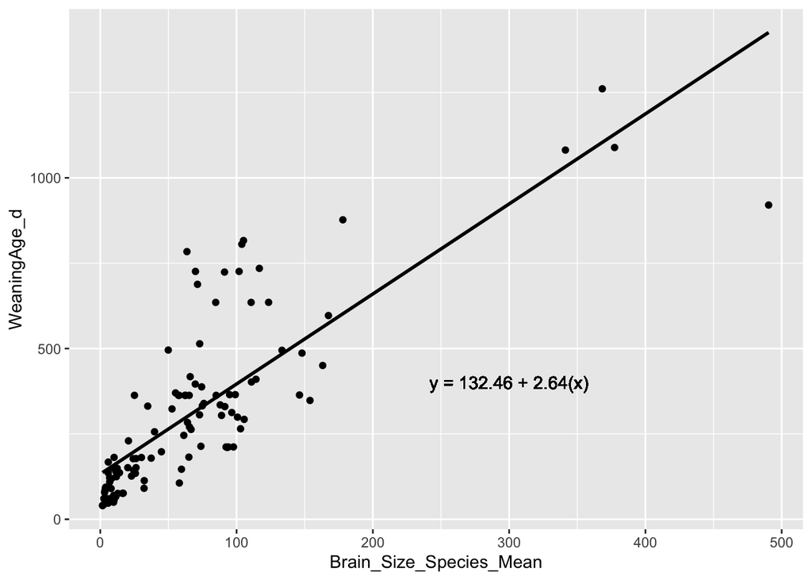

```r
p1 <- ggplot(data = d, aes(x = Brain_Size_Species_Mean, y = WeaningAge_d), na.rm = T)+
               geom_point() +
               geom_smooth(method = "lm", formula = y~x, se = F, color = "black")

#append fitted model equation to plot
p1 <- p1 + geom_text(x = 300, y = 400, label = "y = 132.46 + 2.64(x)", col = "black")
p1
```

Identify and interpret the point estimate of the slope (beta1)

```r
Mod_1.summary <- tidy(Mod_1)

beta1 <- Mod_1.summary %>%
  filter(term == "Brain_Size_Species_Mean") %>%
  pull(estimate)

beta0 <- Mod_1.summary %>%
  filter(term == "(Intercept)") %>%
  pull(estimate)

beta1
```

```
## [1] 2.637107
```

```r
beta0
```

```
## [1] 132.464
```

```r
#test null hypothesis that beta1 = 0
beta1 ==0
```

```
## [1] FALSE
```

```r
#test alternative hypothesis that beta1 does not = 0
beta1!=0
```

```
## [1] TRUE
```

```r
#Rejects the null hypothesis. Beta1 is the true slope; every time the x value increased, the y value will increase by beta1.
```

Find a 90% CI for the slope (βbeta1) parameter. Using your model, add lines for the 90% confidence

```r
ci <- predict(Mod_1,
              newdata = data.frame(Brain_Size_Species_Mean = d$Brain_Size_Species_Mean),
              interval = "confidence", level = 0.9)
ci
```

```
##           fit       lwr       upr
## 1    285.4690  261.3345  309.6034
## 2          NA        NA        NA
## 3    271.8088  247.4128  296.2047
## 4    271.2550  246.8463  295.6636
## 5    268.8025  244.3355  293.2694
## 6    264.0029  239.4127  288.5931
## 7    267.2993  242.7950  291.8036
## 8    278.0851  253.8218  302.3483
## 9    186.9730  158.9221  215.0240
## 10         NA        NA        NA
## 11   175.4489  146.6757  204.2220
## 12         NA        NA        NA
## 13         NA        NA        NA
## 14   176.8993  148.2194  205.5791
```

[output cut: 199 more lines]